# Programming Assignment 4 Writeup

Chris Oakden

Last Updated: 2018-03-01

## Intro

This writeup examines the `fricatives` dataset, which contains acoustic measures for the segments [s] and [sh]. Basic descriptive statsitics and exploratory data analysis are presented. Additionally, a linear model is fit to the data to explore the relationship between center of gravity and vowel skewness in [s] phonemes. The results of the model fit are also discussed.

## Data

This dataset contains center of gravity and skewness measurements for both [s] and [sh] phonemes across 20 experimental observations.

```
## # A tibble: 6 x 4
##     obs phoneme      cog    skewness
##   <int>   <chr>    <dbl>       <dbl>
## 1     1       s 3285.300 -1.21527708
## 2     1      sh 2408.519 -0.24808262
## 3     2       s 4664.371 -1.18544712
## 4     2      sh 2823.398 -0.01652603
## 5     3       s 4679.532 -1.06762330
## 6     3      sh 2898.352  0.11767899
```

## Descriptive Statistics

Mean and standard deviations for center of gravity and skewness for each phoneme are presented in the following table:

[output not shown]

On average, center of gravity for [s] is higher than that of [sh] (see the boxplot below).

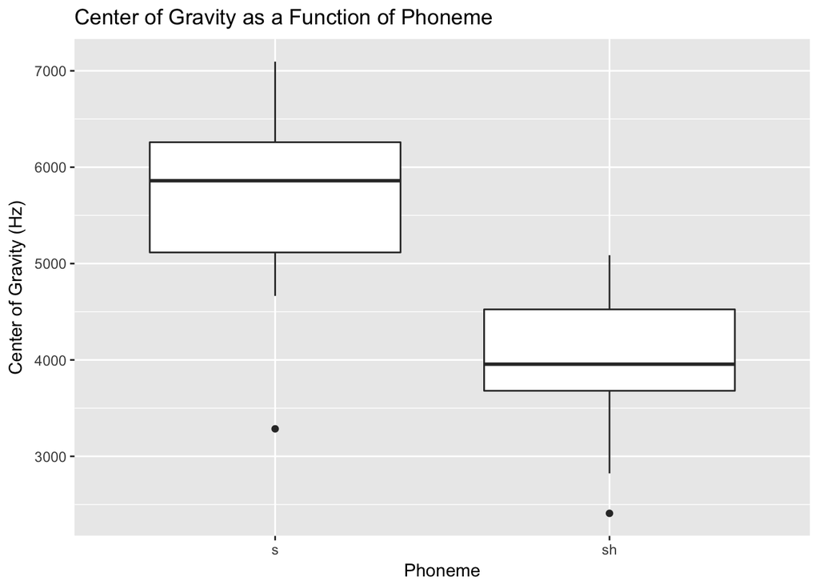

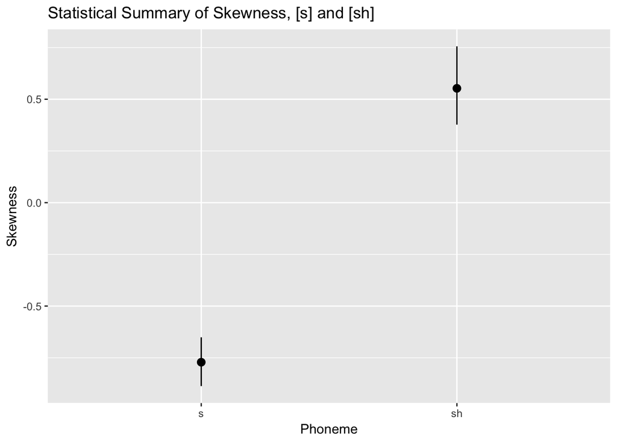

## Linear Model

This writeup aims to examine the relationship between skewness and center of gravity for [s] phonemes. A linear model was fit to the data, setting center of gravity as the dependent variable, and skewness as an independent variable. Summary of the results are presented below.

|  | beta | SE | 95%LB | 95%UB | t-value | p.value |
| --- | --- | --- | --- | --- | --- | --- |
| (Intercept) | 8027 | 212 | 7603 | 8451 | 37.80 | <0.001 |
| skewness | 3029 | 259 | 2511 | 3547 | 11.69 | <0.001 |

The intercept for skewness indicates a positive correlation with gravity. This general tendency is illustrated in the graph below.

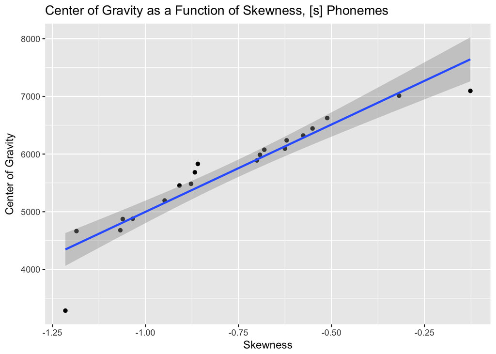

The next section discusses the results of the model and evaluates model diagnostics.

## Discussion

According to the model introduced above, there is a positive correlation between skewness and center of gravity on [s] segments, such that a single unit increase in skewness results in a 3000 Hz increase in center of gravity on average. As center of gravity on an [s] segment increases, so does its skewness; additionally, this effect was found to be significant (p<0.001).  
Analysis of model diagnostics is potentially problematic for this generalization. The mean of the residuals was 0, however the distribution of the 1st and 3rd quartiles suggests unequal variance.

```
##     Min.  1st Qu.   Median     Mean  3rd Qu.     Max.
## -1060.74   -21.72    58.96     0.00   123.00   405.24
```

Heteroskedasticity and non-normality in residuals was found. This finding is in part due to several influential data points, specifically observations 1, 10, and 20. These are shown in the plots below:

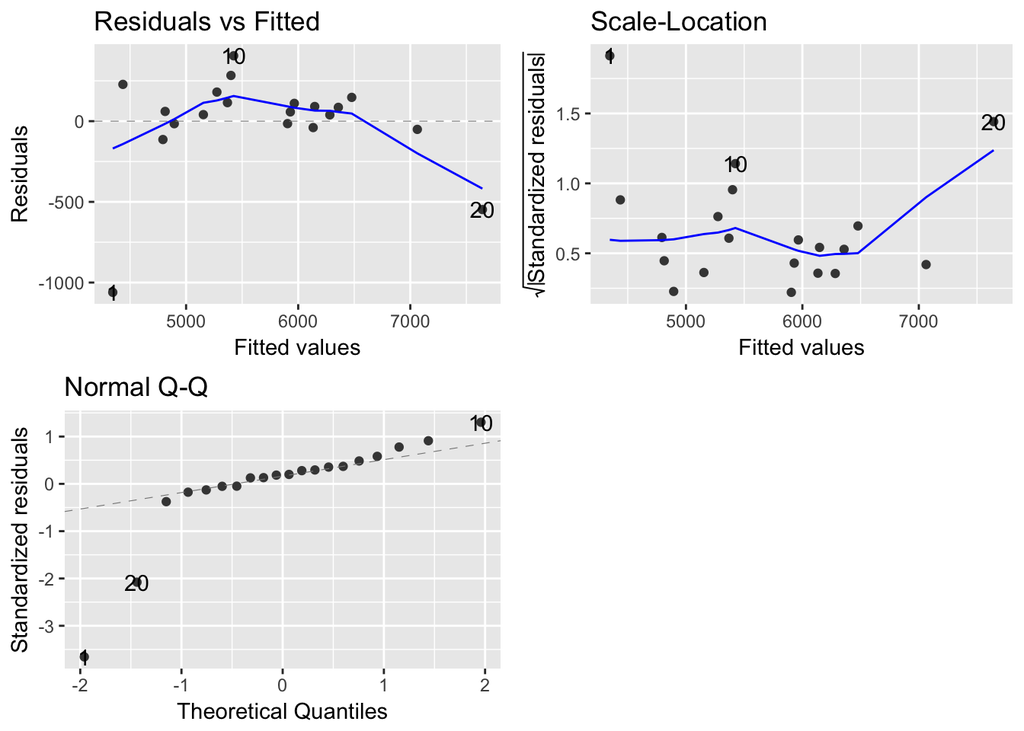

There did not appear, however, to be any autocorrelation of residuals.

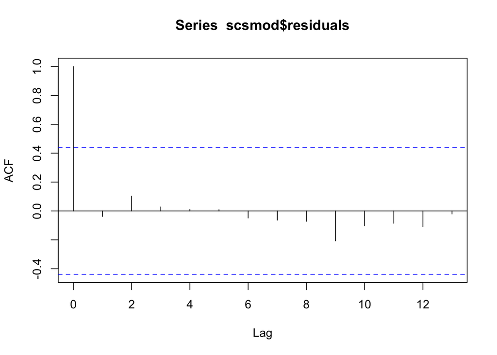

The sample size for the data was small (n=20), therefore more data should be collected to determine whether the influential data points in the current sample are indicative of an actual trend or simple random error.